# Bellabeat Case Study

Caleb

2023-01-13

#Loading Packages

```r
install.packages("tidyverse", repos = "http://cran.us.r-project.org")
install.packages("rmarkdown", repos = "http://cran.us.r-project.org")
```

```r
install.packages("ggplot2", repos = "http://cran.us.r-project.org")
install.packages("dplyr", repos = "http://cran.us.r-project.org")
install.packages("skimr", repos = "http://cran.us.r-project.org")
install.packages("janitor", repos = "http://cran.us.r-project.org")
install.packages("here", repos = "http://cran.us.r-project.org")
library(tidyverse)
library(lubridate)
library(ggplot2)
library(rmarkdown)
library(readr)
library(dplyr)
library(skimr)
library(janitor)
library(here)
```

#Importing and cleaning datasets ##Loading datasets

```r
daily_activity_df <- read_csv("dailyActivity_merged.csv")
sleep_day <- read_csv("sleepDay_merged.csv")
```

##Sorting the Data

```r
daily_activity_df_sorted <- daily_activity_df %>% arrange(Id, ActivityDate)
```

```r
sleep_day_sorted <- sleep_day %>% arrange(Id, SleepDay)
```

##removing original datasets

```r
remove(daily_activity_df)
```

```r
remove(sleep_day)
```

##cleaning names

```r
daily_activity_df_sorted <- clean_names(daily_activity_df_sorted)
```

```r
sleep_day_sorted <- clean_names(sleep_day_sorted)
```

##duplicates

```r
daily_activity_df_sorted <- unique(daily_activity_df_sorted)
```

```r
sleep_day_sorted <- unique(sleep_day_sorted)
```

##removing rows with suspiciously low activity (suspected device not used or died early)

```r
daily_activity_df_sorted <- daily_activity_df_sorted %>% filter(total_steps >= 400, total_distance > 0, tracker_distance > 0)
```

##exporting to fix dates in google sheets

```r
write.csv(sleep_day_sorted, "sleep_day_sorted.csv")
```

```r
write.csv(daily_activity_df_sorted, "daily_activity_sorted.csv")
```

#Importing the datasets from google sheets

```r
#importing fixed datasets prepped for merging

activity_day_fixed <- read.csv("activity_day_fixed.csv")
```

```r
sleep_day_fixed <- read.csv("sleep_day_fixed.csv")
```

#joining datasets

```r
#joining sleep_day_fixed and activity_day_fixed

activity_joined <- merge(x = activity_day_fixed, y = sleep_day_fixed, by = c("date", "id"))
```

##removing old dataframes

```r
remove(daily_activity_df_sorted)
```

```r
remove(sleep_day_sorted)
```

##renaming datasets

```r
daily_activity <- activity_day_fixed
```

```r
remove(activity_day_fixed)
```

```r
sleep_day <- sleep_day_fixed
```

```r
remove(sleep_day_fixed)
```

#Checking distinct IDs since I forgot earlier

```r
n_distinct(sleep_day$id)
```

```
## [1] 24
```

```r
n_distinct(daily_activity$id)
```

```
## [1] 33
```

#Making averages datsets for pie charts #making an averages dataframe for each ID in daily_activity

```r
daily_averages <- daily_activity %>%
  group_by(id) %>%
  summarize(steps = mean(total_steps), distance = mean(total_distance), very_active_distance = mean(very_active_distance), moderately_active_distance = mean(moderately_active_distance),
            light_active_distance = mean(light_active_distance), very_active_minutes = mean(very_active_minutes), fairly_active_minutes = mean(fairly_active_minutes),
            lightly_active_minutes = mean(lightly_active_minutes), sedentary_minutes = mean(sedentary_minutes), average_calories = mean(calories))
```

#making an averages dataframe for the activity_joined to include sleep analysis

```r
sleep_averages <- activity_joined %>%
  group_by(id) %>%
  summarize(steps = mean(total_steps), distance = mean(total_distance), very_active_distance = mean(very_active_distance), moderately_active_distance = mean(moderately_active_distance),
            light_active_distance = mean(light_active_distance), very_active_minutes = mean(very_active_minutes), fairly_active_minutes = mean(fairly_active_minutes),
            lightly_active_minutes = mean(lightly_active_minutes), sedentary_minutes = mean(sedentary_minutes), average_calories = mean(calories),
            average_min_asleep = mean(total_minutes_asleep), average_time_in_bed = mean(total_time_in_bed))
```

#Making user classifications based averages

##classifying users based on steps according to https://www.10000steps.org.au/articles/healthy-lifestyles/counting-steps/ ##this allows me to see how many users are active or not to get an idea of the users

```r
activity_status <- daily_averages %>%
  mutate(activity_status = case_when(steps < 5000 ~ "Sedentary", steps >= 5000 & steps <= 7499 ~ "Low Activity", steps >= 7500 & steps <= 9999 ~ "Medium Activity",
                                     steps >= 10000 & steps < 12500 ~ "Active", steps >= 12500 ~ "High Activity"))
```

##daily step analysis - not used in final analysis

```r
daily_steps <- daily_activity %>%
  mutate(activity_status = case_when(total_steps < 5000 ~ "Sedentary", total_steps >= 5000 & total_steps <= 7499 ~ "Low Activity",
                                     total_steps >= 7500 & total_steps <= 9999 ~ "Medium Activity", total_steps >= 10000 & total_steps < 12500 ~ "Active",
                                     total_steps >= 12500 ~ "High Activity"))
```

##Calculating users sleep based on mayo clinic recommendations for adults. 7-9 hours is the recommended.

```r
sleep_status <- sleep_averages %>%
  mutate(sleep_duration = case_when(average_min_asleep < 420 ~ "Too Little", average_min_asleep >= 420 & average_min_asleep <= 540 ~ "Good", average_min_asleep > 540 ~ "Too Much"))
```

##daily sleep analysis - not used in final analysis

```r
daily_sleep <- sleep_day %>%
  mutate(sleep_duration = case_when(total_minutes_asleep < 420 ~ "Too Little", total_minutes_asleep >= 420 & total_minutes_asleep <= 540 ~ "Good", total_minutes_asleep >540 ~ "Too Much"))
```

#creating another dataset including activity, sleep, and all ratings

```r
#activity joined + sleep duration rating

activity_join_plus <- activity_joined %>%
  mutate(sleep_duration = case_when(total_minutes_asleep < 420 ~ "Too Little", total_minutes_asleep >= 420 & total_minutes_asleep <= 540 ~ "Good", total_minutes_asleep > 540 ~ "Too Much")) %>%
  mutate(activity_status = case_when(total_steps < 5000 ~ "Sedentary", total_steps >= 5000 & total_steps <= 7499 ~ "Low Activity",
                                     total_steps >= 7500 & total_steps <= 9999 ~ "Medium Activity", total_steps >= 10000 & total_steps < 12500 ~ "Active",
                                     total_steps >= 12500 ~ "High Activity"))
```

#creating datasets based on activity and sleep status

##analyzing percentages of sleep and activity to get an idea of who is using these products

##activity_status using all daily inputs - not used

```r
daily_activity_percents <- daily_steps %>%
  group_by(activity_status) %>%
  summarize(daily_activity_percent = 100 * n() / nrow(daily_steps))
```

##average activity status per user

```r
avg_activity_percents <- activity_status %>%
  group_by(activity_status) %>%
  summarize(average_activity_percent = 100 * n() / nrow(activity_status))
```

#getting percents for sleep trends

##avg sleep % for each user

```r
avg_sleep_percent <- sleep_status %>%
  group_by(sleep_duration) %>%
  summarize(average_sleep_percent = 100 * n() / nrow(sleep_status))
```

##daily sleep % based on all daily inputs - not used

```r
daily_sleep_percent <- daily_sleep %>%
  group_by(sleep_duration) %>%
  summarize(daily_sleep_percent = 100 * n() / nrow(daily_sleep))
```

#rounding the numbers form those percentage sets

```r
#rounding the numbers

avg_activity_percents <- avg_activity_percents %>% mutate_if(is.numeric, round, digits = 2)
```

```
## `mutate_if()` ignored the following grouping variables:
## • Column `activity_status`
```

```r
daily_activity_percents <- daily_activity_percents %>% mutate_if(is.numeric, round, digits = 2)
avg_sleep_percent <- avg_sleep_percent %>% mutate_if(is.numeric, round, digits = 2)
daily_sleep_percent <- daily_sleep_percent %>% mutate_if(is.numeric, round, digits = 2)
```

#exporting those datasets to make pie charts in google sheets

```r
write_csv(avg_activity_percents, "avg_activity_percents.csv")
```

```r
write_csv(avg_sleep_percent, "avg_sleep_percent.csv")
```

```r
write_csv(daily_activity_percents, "daily_activity_percents.csv")
```

```r
write_csv(daily_sleep_percent, "daily_sleep_percent.csv")
```

#graphing daily steps compared to calories

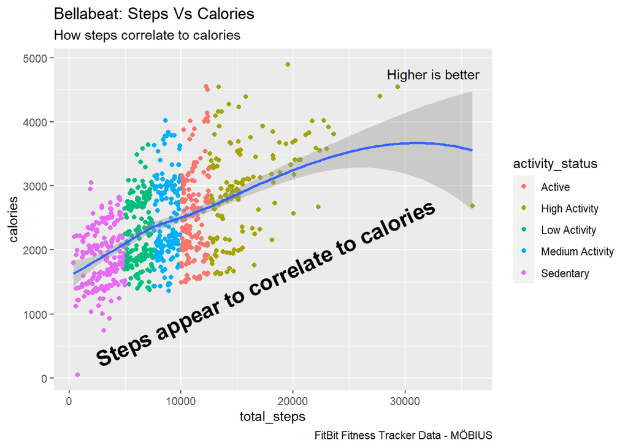

```r
#graphing daily_steps

ggplot(data = daily_steps, mapping = aes(x = total_steps, y = calories)) +
  geom_point(aes(color = activity_status))+
  geom_smooth() +
  labs(title = "Bellabeat: Steps Vs Calories", subtitle = "How steps correlate to calories", caption = "FitBit Fitness Tracker Data - MÖBIUS") +
  annotate("text", x = 17500, y = 1500, label = "Steps appear to correlate to calories", fontface = "bold", angle = 25, size = 6) +
  annotate("text", x = 32500, y = 4750, label = "Higher is better")
```

#creating long data to graph the different activity classifications

```r
#creating longer data for daily_steps to graph activity minutes

daily_steps_long <- daily_steps %>%
  select(id, date, lightly_active_minutes, sedentary_minutes, very_active_minutes, fairly_active_minutes, calories, activity_status, total_steps) %>%
  pivot_longer(cols = c(lightly_active_minutes, sedentary_minutes, very_active_minutes, fairly_active_minutes), names_to = "Var", values_to = "Val")
```

```r
activity_joined_plus_long <- activity_join_plus %>%
  select(id, date, lightly_active_minutes, sedentary_minutes, very_active_minutes, fairly_active_minutes, calories, total_minutes_asleep, sleep_duration, activity_status) %>%
  pivot_longer(cols = c(lightly_active_minutes, sedentary_minutes, very_active_minutes, fairly_active_minutes), names_to = "Var", values_to = "Val")
```

#graphing the long data

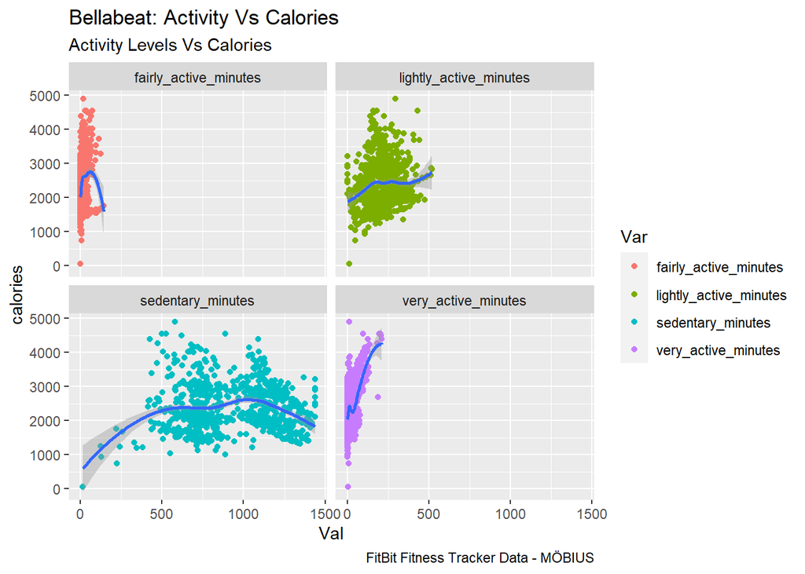

```r
ggplot(data = daily_steps_long, mapping = aes(x = Val, y = calories)) +
  geom_point(aes(color = Var)) +
  geom_smooth() +
  facet_wrap(~Var) +
  labs(title = "Bellabeat: Activity Vs Calories", subtitle = "Activity Levels Vs Calories", caption = "FitBit Fitness Tracker Data - MÖBIUS")
```

#graphing the above charts seperately to zone in ##graphing very active minutes

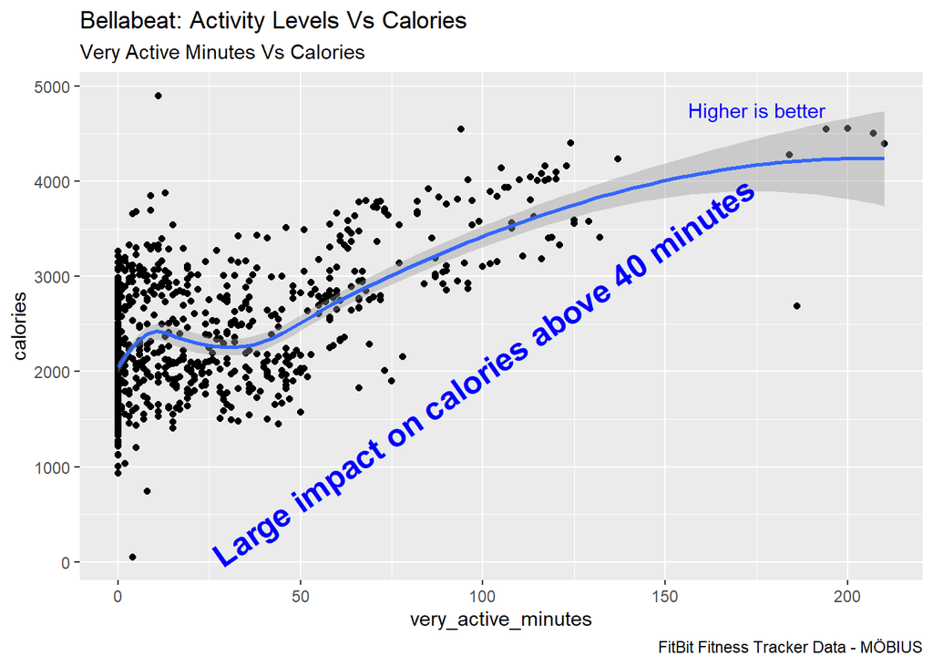

```r
ggplot(data = daily_steps, mapping = aes(x = very_active_minutes, y = calories)) +
  geom_point() +
  geom_smooth() +
  labs(title = "Bellabeat: Activity Levels Vs Calories", subtitle = "Very Active Minutes Vs Calories", caption = "FitBit Fitness Tracker Data - MÖBIUS") +
  annotate("text", x = 100, y = 2000, label = "Large impact on calories above 40 minutes", angle = 35, fontface = "bold", size = 6, color = "blue") +
  annotate("text", x = 175, y = 4750, label = "Higher is better", color = "blue")
```

##fairly active minutes graph

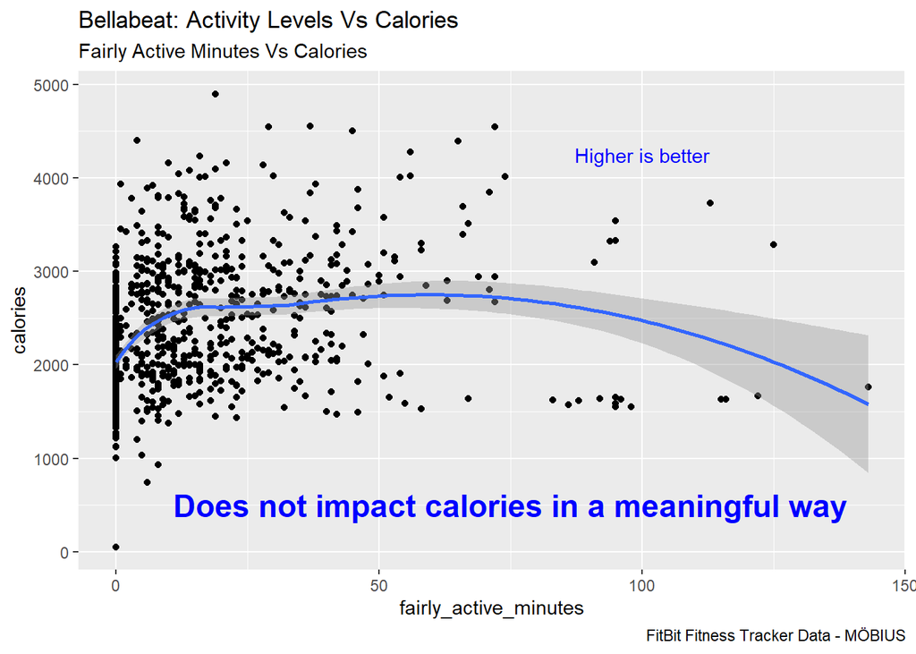

```r
ggplot(data = daily_steps, mapping = aes(x = fairly_active_minutes, y = calories)) +
  geom_point() +
  geom_smooth() +
  labs(title = "Bellabeat: Activity Levels Vs Calories", subtitle = "Fairly Active Minutes Vs Calories", caption = "FitBit Fitness Tracker Data - MÖBIUS") +
  annotate("text", x = 75, y = 500, label = "Does not impact calories in a meaningful way", fontface = "bold", size = 6, color = "blue") +
  annotate("text", x = 100, y = 4250, label = "Higher is better", color = "blue")
```

##graphing lightly active minutes

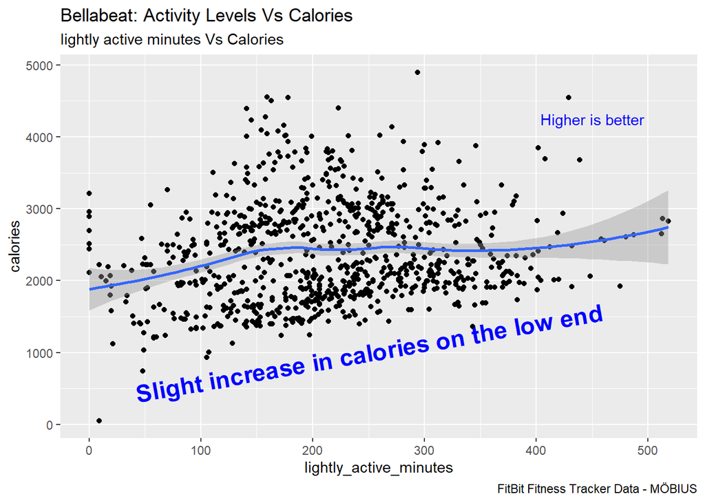

```r
ggplot(data = daily_steps, mapping = aes(x = lightly_active_minutes, y = calories)) +
  geom_point() +
  geom_smooth() +
  labs(title = "Bellabeat: Activity Levels Vs Calories", subtitle = "lightly active minutes Vs Calories", caption = "FitBit Fitness Tracker Data - MÖBIUS") +
  annotate("text", x = 250, y = 1000, label = "Slight increase in calories on the low end", color = "blue", fontface = "bold", angle = 10, size = 6) +
  annotate("text", x = 450, y = 4250, label = "Higher is better", color = "blue")
```

##graphing sedentary minutes

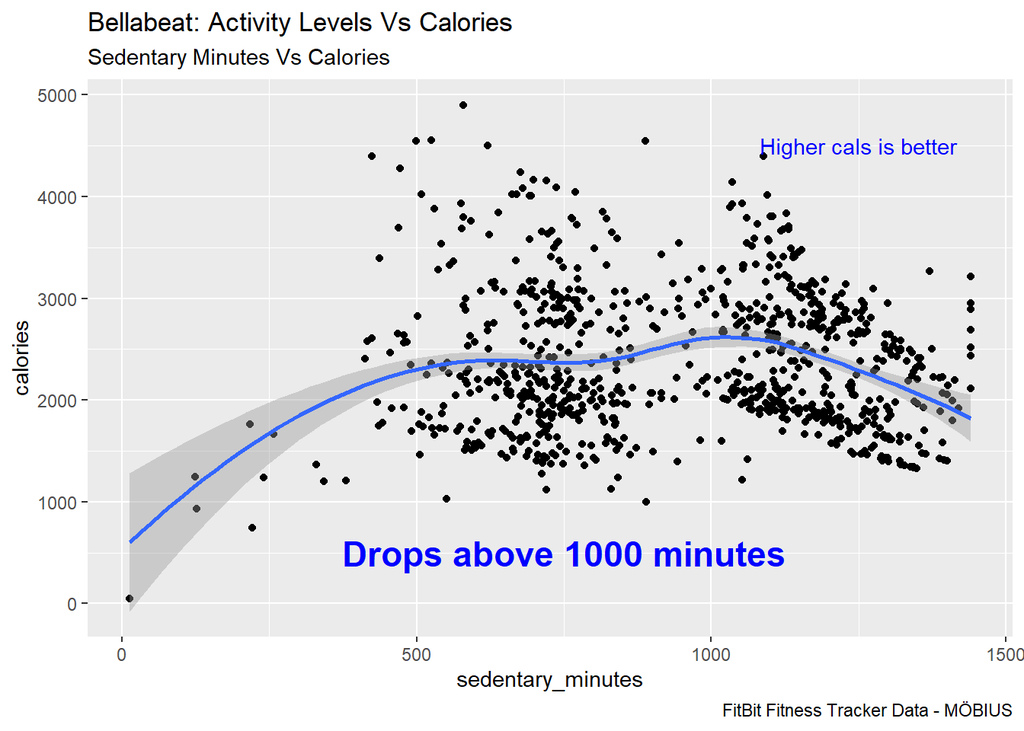

```r
ggplot(data = daily_steps, mapping = aes(x = sedentary_minutes, y = calories)) +
  geom_point() +
  geom_smooth() +
  labs(title = "Bellabeat: Activity Levels Vs Calories", subtitle = "Sedentary Minutes Vs Calories", caption = "FitBit Fitness Tracker Data - MÖBIUS") +
  annotate("text", x = 750, y = 500, label = "Drops above 1000 minutes", color = "blue", fontface = "bold", size = 6) +
  annotate("text", x = 1250, y = 4500, label = "Higher cals is better", color = "blue")
```

#graphing sleep related data ##graphing sleep and calories

[figure not shown]

```r
ggplot(data = activity_joined_plus_long, mapping = aes(x = total_minutes_asleep, y = calories)) +
  geom_point(aes(color = sleep_duration)) +
  geom_smooth() +
  scale_x_continuous(breaks = seq(0, 800, by = 100)) +
  labs(title = "Bellabeat: Sleep Vs Calories", subtitle = "Sleep Duration Vs Calories", caption = "FitBit Fitness Tracker Data - MÖBIUS") +
  annotate("text", x = 425, y = 1000, label = "Calorie burn is highest in the 5.5-9 hours of sleep range", size = 4, fontface = "bold") +
  annotate("text", x = 700, y = 4500, label = "Higher is better")
```

##sleep to sedentary minutes

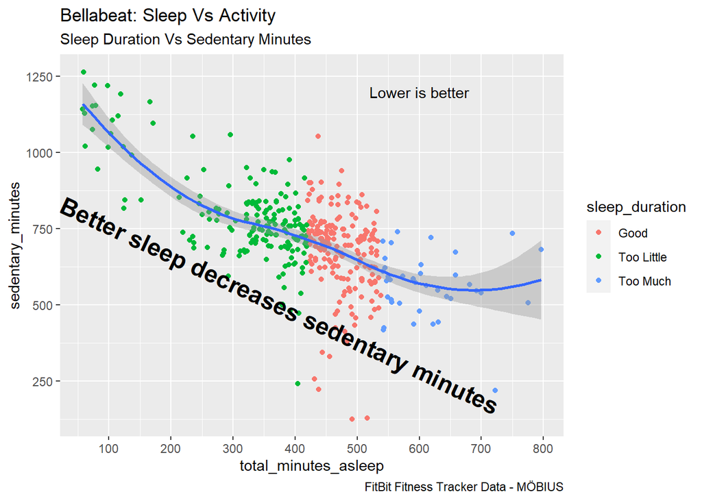

```r
ggplot(data = activity_join_plus, mapping = aes(x = total_minutes_asleep, y = sedentary_minutes)) +
  geom_point(aes(color = sleep_duration)) +
  geom_smooth() +
  scale_x_continuous(breaks = seq(0, 800, by = 100)) +
  labs(title = "Bellabeat: Sleep Vs Activity", subtitle = "Sleep Duration Vs Sedentary Minutes", caption = "FitBit Fitness Tracker Data - MÖBIUS") +
  annotate("text", x = 375, y = 500, label = "Better sleep decreases sedentary minutes", size = 6, angle = 335, fontface = "bold") +
  annotate("text", x = 600, y = 1200, label = "Lower is better")
```

##sleep to very active minutes

[figure not shown]

```r
ggplot(data = activity_join_plus, mapping = aes(x = total_minutes_asleep, y = very_active_minutes)) +
  geom_point(aes(color = sleep_duration)) +
  geom_smooth() +
  scale_x_continuous(breaks = seq(0, 800, by = 100)) +
  labs(title = "Bellabeat: Sleep Vs Activity", subtitle = "Sleep Duration Vs Very Active Minutes", caption = "FitBit Fitness Tracker Data - MÖBIUS") +
  annotate("text", x = 425, y = 150, label = "Increases with better sleep", size = 6, fontface = "bold") +
  annotate("text", x = 425, y = -25, label = "decreases with too much sleep", size = 6, fontface = "bold") +
  annotate("text", x = 700, y = 200, label = "higher is better")
```

##sleep to fairly active minutes

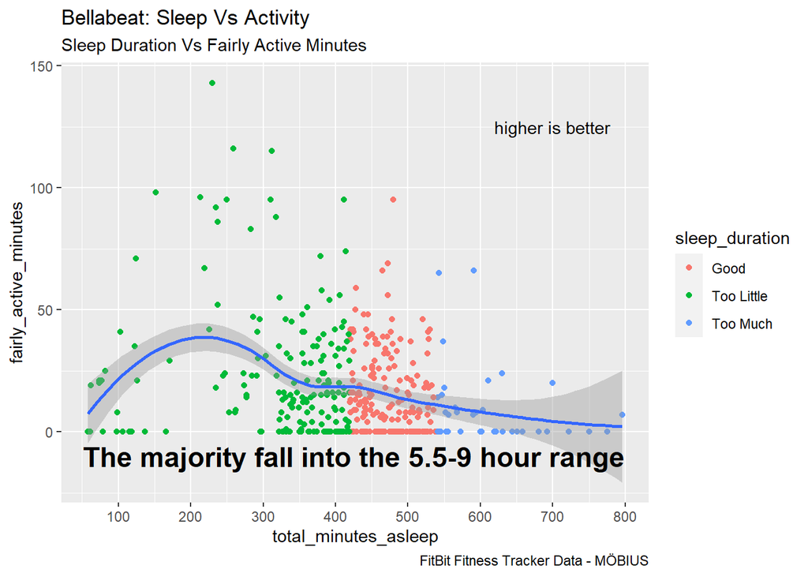

```r
ggplot(data = activity_join_plus, mapping = aes(x = total_minutes_asleep, y = fairly_active_minutes)) +
  geom_point(aes(color = sleep_duration)) +
  geom_smooth() +
  scale_x_continuous(breaks = seq(0, 800, by = 100)) +
  labs(title = "Bellabeat: Sleep Vs Activity", subtitle = "Sleep Duration Vs Fairly Active Minutes", caption = "FitBit Fitness Tracker Data - MÖBIUS") +
  annotate("text", x = 425, y = -10, label = "The majority fall into the 5.5-9 hour range", fontface = "bold", size = 6) +
  annotate("text", x = 700, y = 125, label = "higher is better")
```

##sleep to lightly active minutes

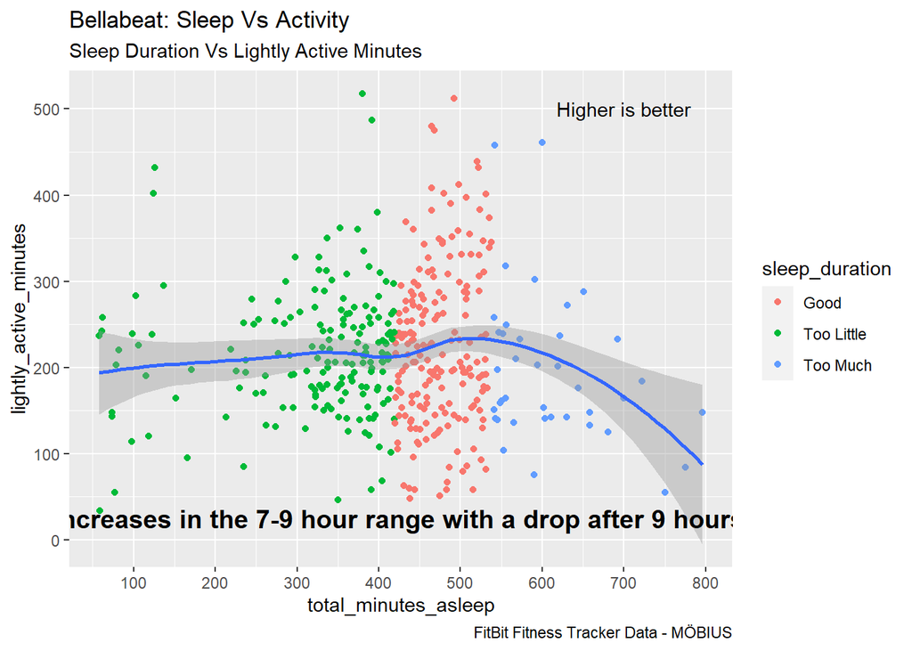

```r
ggplot(data = activity_join_plus, mapping = aes(x = total_minutes_asleep, y = lightly_active_minutes)) +
  geom_point(aes(color = sleep_duration)) +
  geom_smooth() +
  scale_x_continuous(breaks = seq(0, 800, by = 100)) +
  labs(title = "Bellabeat: Sleep Vs Activity", subtitle = "Sleep Duration Vs Lightly Active Minutes", caption = "FitBit Fitness Tracker Data - MÖBIUS") +
  annotate("text", x = 425, y = 25, label = "Increases in the 7-9 hour range with a drop after 9 hours", fontface = "bold", size = 5) +
  annotate("text", x = 700, y = 500, label = "Higher is better")
```

#From this point graphs were exported and used in google slides to make a presentation